# Predict Product Category from Invoice - Hacker Earth

### Train Test Splitting

```python
X_train, X_test, y_train, y_test = train_test_split(X, y, test_size=0.33, random_state=42)
```

```python
X_train[:5]
```

```
array([[64.02,  0.  ,  0.  , ...,  0.  ,  0.  ,  0.  ],
       [30.54,  0.  ,  0.  , ...,  0.  ,  0.  ,  0.  ],
       [83.38,  0.  ,  0.  , ...,  0.  ,  0.  ,  0.  ],
       [49.72,  0.  ,  0.  , ...,  0.  ,  0.  ,  0.  ],
       [ 8.19,  0.  ,  0.  , ...,  0.  ,  0.  ,  0.  ]])
```

```python
y_train[:5] # Encoded values
```

```
array([15,  7, 22, 20, 25], dtype=int64)
```

#### Target Distribution in both **Train** and **Test** Check

##### Train

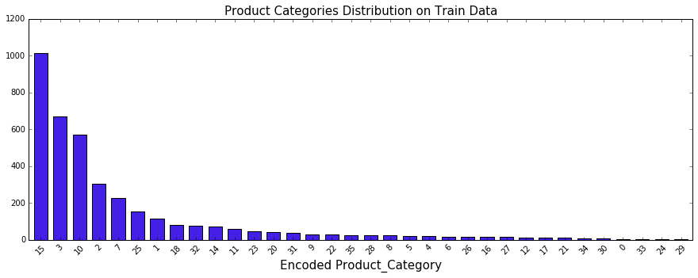

```python
plt.figure(figsize=(15,5))

asthetic_size=15
pd.value_counts(y_train).plot('bar',color='#441FE6',width=.7)
plt.title("Product Categories Distribution on Train Data",size=asthetic_size)
plt.xlabel("Encoded Product_Category",size=asthetic_size)
plt.xticks(rotation=45)
plt.show()
```

##### Test

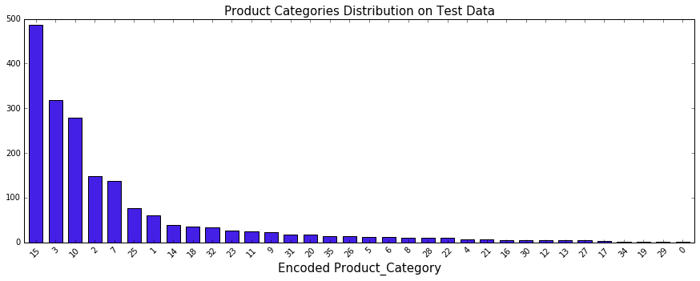

```python
plt.figure(figsize=(15,5))

asthetic_size=15
pd.value_counts(y_test).plot('bar',color='#441FE6',width=0.7)
plt.title("Product Categories Distribution on Test Data",size=asthetic_size)
plt.xlabel("Encoded Product_Category",size=asthetic_size)
plt.xticks(rotation=45)
plt.show()
```

Since Proportion of each class is simillar in both **Train** and **Test**. We can assume Splitting done a **great job**!

### Model Building

```python
clf = RandomForestClassifier(n_estimators=100,random_state=0)
```

```python
clf.fit(X_train,y_train) # Fitting
```

```
RandomForestClassifier(bootstrap=True, class_weight=None, criterion='gini',
            max_depth=None, max_features='auto', max_leaf_nodes=None,
            min_impurity_decrease=0.0, min_impurity_split=None,
            min_samples_leaf=1, min_samples_split=2,
            min_weight_fraction_leaf=0.0, n_estimators=100, n_jobs=1,
            oob_score=False, random_state=0, verbose=0, warm_start=False)
```

```python
clf.predict(X_test) # Predictions
```

```
array([15, 15, 15, ...,  3, 10,  2], dtype=int64)
```

### Accuracy

```python
print("Accuracy: {}".format(round(accuracy_score(y_test, clf.predict(X_test)),3)))
```

```
Accuracy: 0.996
```

```python
cm=confusion_matrix(y_test,clf.predict(X_test))
cm
```

```
array([[  1,   0,   0, ...,   0,   0,   0],
       [  0,  60,   0, ...,   0,   0,   0],
       [  0,   0, 147, ...,   0,   0,   0],
       ...,
       [  0,   0,   0, ...,  34,   0,   0],
       [  0,   0,   0, ...,   0,   0,   0],
       [  0,   0,   0, ...,   0,   0,  13]], dtype=int64)
```

### Confusion Matrix

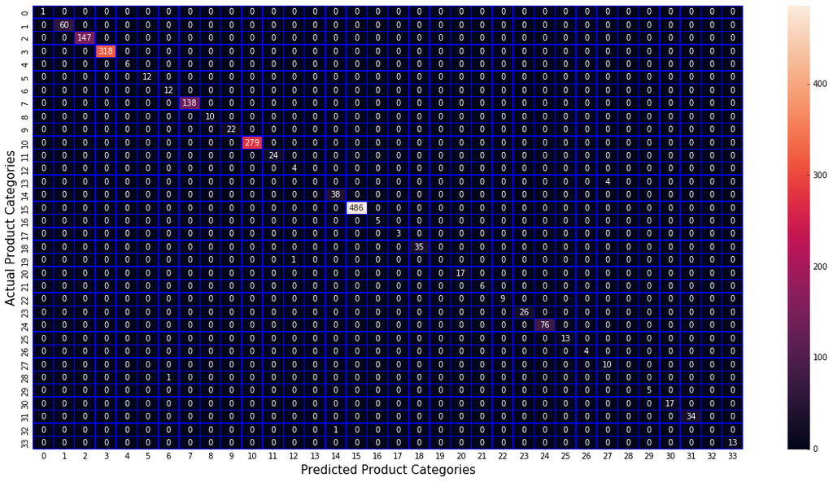

```python
import seaborn as sns
f, ax=plt.subplots(figsize=(20,10))
sns.heatmap(cm,annot=True,linewidths=0.5,linecolor="blue",fmt=".0f",ax=ax)
plt.xlabel("Predicted Product Categories",size=15)
plt.ylabel("Actual Product Categories",size=15)
```

### Precision, Recall & F1-Score

**Classification Report** of the Classifier across all **product cateogories**

```python
print(classification_report(y_test, clf.predict(X_test)))
```

```
             precision    recall  f1-score   support

          0       1.00      1.00      1.00         1
          1       1.00      1.00      1.00        60
          2       1.00      1.00      1.00       147
          3       1.00      1.00      1.00       318
          4       1.00      1.00      1.00         6
          5       1.00      1.00      1.00        12
          6       0.92      1.00      0.96        12
          7       1.00      1.00      1.00       138
          8       1.00      1.00      1.00        10
          9       1.00      1.00      1.00        22
         10       1.00      1.00      1.00       279
         11       1.00      1.00      1.00        24
         12       0.80      1.00      0.89         4
```

[output cut: 23 more lines]

### Five Fold Cross Validation

```python
kfold=KFold(n_splits=5)
```

```python
scores = cross_val_score(clf, X, y, cv=kfold,scoring="accuracy",n_jobs=-1)
```

```python
for i,fold_res in enumerate(scores):
    print("**Fold-{}** Accuracy: {}".format(i+1,round(fold_res,3)))
```

```
**Fold-1** Accuracy: 0.998
**Fold-2** Accuracy: 0.998
**Fold-3** Accuracy: 1.0
**Fold-4** Accuracy: 0.999
**Fold-5** Accuracy: 0.998
```

On Each and every Fold we are getting around same accuracy with **Minor varience**. So our **Classifier** is doing good job!

### **Visualizing** the **Cross Validation** results

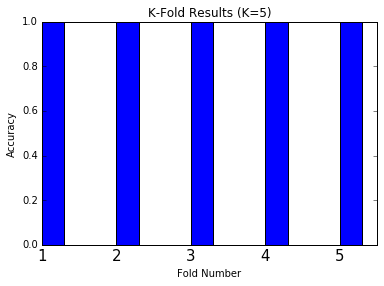

```python
# fig, ax = plt.subplots(figsize=(6,2))
plt.bar(range(1,6),scores,width=0.3)
plt.xlabel("Fold Number",size=10)
plt.ylabel("Accuracy",size=10)
plt.title("K-Fold Results (K=5)")
plt.xticks([1,2,3,4,5],size=15)
plt.show()
```

### Final Predictions of Test Data (Provided):

```python
test_data.head()
```

|  | Inv_Id | Vendor_Code | GL_Code | Inv_Amt | Item_Description |
| --- | --- | --- | --- | --- | --- |
| 0 | 15003 | VENDOR-2513 | GL-6050310 | 56.13 | Travel and Entertainment Miscellaneous Company... |
| 1 | 15008 | VENDOR-1044 | GL-6101400 | 96.56 | Final Site Clean Up Store Construction Advance... |
| 2 | 15013 | VENDOR-1254 | GL-6101400 | 55.93 | Arabian American Development Co Final Site Cle... |
| 3 | 15019 | VENDOR-1331 | GL-2182000 | 32.62 | Corporate Services Contingent Labor/Temp Labor... |
| 4 | 15020 | VENDOR-2513 | GL-6050310 | 25.81 | Fortune National Corp Miscellaneous Company Ca... |

```python
test_data_Desc_CV = cv.transform(test_data.Item_Description)
```

```python
test_data_Final = pd.concat([test_data[['Inv_Amt']],pd.DataFrame(test_data_Desc_CV.toarray())],axis=1)
```

```python
le.inverse_transform(clf.predict(test_data_Final))
```

```
array(['CLASS-1758', 'CLASS-1522', 'CLASS-1522', ..., 'CLASS-1250',
       'CLASS-1963', 'CLASS-1964'], dtype=object)
```

```python
test_data['Product_Category']=le.inverse_transform(clf.predict(test_data_Final))
```

```python
test_data.head()
```

|  | Inv_Id | Vendor_Code | GL_Code | Inv_Amt | Item_Description | Product_Category |
| --- | --- | --- | --- | --- | --- | --- |
| 0 | 15003 | VENDOR-2513 | GL-6050310 | 56.13 | Travel and Entertainment Miscellaneous Company... | CLASS-1758 |
| 1 | 15008 | VENDOR-1044 | GL-6101400 | 96.56 | Final Site Clean Up Store Construction Advance... | CLASS-1522 |
| 2 | 15013 | VENDOR-1254 | GL-6101400 | 55.93 | Arabian American Development Co Final Site Cle... | CLASS-1522 |
| 3 | 15019 | VENDOR-1331 | GL-2182000 | 32.62 | Corporate Services Contingent Labor/Temp Labor... | CLASS-1376 |
| 4 | 15020 | VENDOR-2513 | GL-6050310 | 25.81 | Fortune National Corp Miscellaneous Company Ca... | CLASS-1758 |

### Saving the FINAL Results

##### Final Submissions on Test Data

- Saving the results into **CSV** as specified format for further Evaluation.

```python
test_data[["Inv_Id","Product_Category"]].to_csv("Final_Submissions.csv",index=False)
```

#### Model Pickilling

- Saved the model as pickle File for later use in production

```python
with open("FinalModel.pickle",'wb') as f:
    pickle.dump(clf,f)
```

#### FInal Sample Predictions of Test Data

```python
test_data.head()
```

|  | Inv_Id | Vendor_Code | GL_Code | Inv_Amt | Item_Description | Product_Category |
| --- | --- | --- | --- | --- | --- | --- |
| 0 | 15003 | VENDOR-2513 | GL-6050310 | 56.13 | Travel and Entertainment Miscellaneous Company... | CLASS-1758 |
| 1 | 15008 | VENDOR-1044 | GL-6101400 | 96.56 | Final Site Clean Up Store Construction Advance... | CLASS-1522 |
| 2 | 15013 | VENDOR-1254 | GL-6101400 | 55.93 | Arabian American Development Co Final Site Cle... | CLASS-1522 |
| 3 | 15019 | VENDOR-1331 | GL-2182000 | 32.62 | Corporate Services Contingent Labor/Temp Labor... | CLASS-1376 |
| 4 | 15020 | VENDOR-2513 | GL-6050310 | 25.81 | Fortune National Corp Miscellaneous Company Ca... | CLASS-1758 |